# u02

## Shared Qs (u02)

#### Question

1. *S-IC.A.2: Decide if a specified model is consistent with results from a given data-generating process, e.g., using simulation.*

   On an alien planet, adult blue-coated bullfrogs’ masses are normally distributed with a mean equaling $\mu=360$ grams and a standard deviation equaling $\sigma=19$ grams. You can simulate measuring a random bullfrog’s mass with `=NORMINV(RAND(),360,19)` in a spreadsheet.

   You “cultivate” some of these bullfrogs on your spaceship. You find that in a sample of $n=6$ adult bullfrogs, you get a sample mean $\bar{x}=346.76$ grams.

   You wonder whether the spaceship conditions have caused a [significant](https://en.wikipedia.org/wiki/Statistical_significance) change in average mass. To answer this, you repeatedly simulate the [null hypothesis](https://en.wikipedia.org/wiki/Null_hypothesis). To do this, you simulate getting the mean mass from 6 adults from the alien planet, and repeat that simulation 1000 times. From those 1000 repetitions, you will get 1000 means. Find the 2.5th percentile and the 97.5th percentile to get the interval of typical means. (Pick the closest answer.)
   - Lower boundary of interval of typical means:
   - Upper boundary of interval of typical means:

   Is the result of a sample mean equaling $\bar{x}=346.76$ grams, with sample size of $n=6$ bullfrogs, consistent with the simulation’s interval of typical means?
   - Is the result consistent with simulation?

#### Solution

#### Question

2. *S-IC.A.2: Decide if a specified model is consistent with results from a given data-generating process, e.g., using simulation.*

   On an alien planet, adult blue-coated bullfrogs’ masses are normally distributed with a mean equaling $\mu=420$ grams and a standard deviation equaling $\sigma=25$ grams. You can simulate measuring a random bullfrog’s mass with `=NORMINV(RAND(),420,25)` in a spreadsheet.

   You “cultivate” some of these bullfrogs on your spaceship. You find that in a sample of $n=7$ adult bullfrogs, you get a sample mean $\bar{x}=441.6$ grams.

   You wonder whether the spaceship conditions have caused a [significant](https://en.wikipedia.org/wiki/Statistical_significance) change in average mass. To answer this, you repeatedly simulate the [null hypothesis](https://en.wikipedia.org/wiki/Null_hypothesis). To do this, you simulate getting the mean mass from 7 adults from the alien planet, and repeat that simulation 1000 times. From those 1000 repetitions, you will get 1000 means. Find the 2.5th percentile and the 97.5th percentile to get the interval of typical means. (Pick the closest answer.)
   - Lower boundary of interval of typical means:
   - Upper boundary of interval of typical means:

   Is the result of a sample mean equaling $\bar{x}=441.6$ grams, with sample size of $n=7$ bullfrogs, consistent with the simulation’s interval of typical means?
   - Is the result consistent with simulation?

#### Solution

#### Question

3. *S-IC.A.2: Decide if a specified model is consistent with results from a given data-generating process, e.g., using simulation.*

   On an alien planet, adult blue-coated bullfrogs’ masses are normally distributed with a mean equaling $\mu=580$ grams and a standard deviation equaling $\sigma=9$ grams. You can simulate measuring a random bullfrog’s mass with `=NORMINV(RAND(),580,9)` in a spreadsheet.

   You “cultivate” some of these bullfrogs on your spaceship. You find that in a sample of $n=15$ adult bullfrogs, you get a sample mean $\bar{x}=576.32$ grams.

   You wonder whether the spaceship conditions have caused a [significant](https://en.wikipedia.org/wiki/Statistical_significance) change in average mass. To answer this, you repeatedly simulate the [null hypothesis](https://en.wikipedia.org/wiki/Null_hypothesis). To do this, you simulate getting the mean mass from 15 adults from the alien planet, and repeat that simulation 1000 times. From those 1000 repetitions, you will get 1000 means. Find the 2.5th percentile and the 97.5th percentile to get the interval of typical means. (Pick the closest answer.)
   - Lower boundary of interval of typical means:
   - Upper boundary of interval of typical means:

   Is the result of a sample mean equaling $\bar{x}=576.32$ grams, with sample size of $n=15$ bullfrogs, consistent with the simulation’s interval of typical means?
   - Is the result consistent with simulation?

#### Solution

#### Question

4. *S-IC.B.4: Use data from a sample survey to estimate a population mean or proportion; develop a margin of error through the use of simulation models for random sampling.*

   A scientist wants to estimate the average mass of adult lab rats under certain conditions. She randomly selects a sample of $n=9$ mice from the population, and finds their masses in grams, to the nearest gram.

   | 491 | 493 | 485 | 473 | 469 | 494 | 454 | 468 | 476 |
   | --- | --- | --- | --- | --- | --- | --- | --- | --- |

   Your goals are:
   - Decide a best estimate for the population mean. (Hint: the sample mean.)
   - Find a 95% [confidence interval](https://en.wikipedia.org/wiki/Confidence_interval) by resampling 1000 times.
   - Find the margin of error (by dividing the interval width by 2).

   Your answers (pick closest to your answer):
   - What is the best estimate for the population mean? grams.
   - Lower boundary of confidence interval = grams.
   - Upper boundary of confidence interval = grams.
   - Margin of error =

#### Solution

#### Question

5. *S-IC.B.4: Use data from a sample survey to estimate a population mean or proportion; develop a margin of error through the use of simulation models for random sampling.*

   A scientist wants to estimate the average mass of adult lab rats under certain conditions. She randomly selects a sample of $n=11$ mice from the population, and finds their masses in grams, to the nearest gram.

   | 479 | 486 | 496 | 490 | 473 | 466 | 482 | 469 | 502 | 459 | 473 |
   | --- | --- | --- | --- | --- | --- | --- | --- | --- | --- | --- |

   Your goals are:
   - Decide a best estimate for the population mean. (Hint: the sample mean.)
   - Find a 95% [confidence interval](https://en.wikipedia.org/wiki/Confidence_interval) by resampling 1000 times.
   - Find the margin of error (by dividing the interval width by 2).

   Your answers (pick closest to your answer):
   - What is the best estimate for the population mean? grams.
   - Lower boundary of confidence interval = grams.
   - Upper boundary of confidence interval = grams.
   - Margin of error =

#### Solution

#### Question

6. *S-IC.B.4: Use data from a sample survey to estimate a population mean or proportion; develop a margin of error through the use of simulation models for random sampling.*

   A scientist wants to estimate the average mass of adult lab rats under certain conditions. She randomly selects a sample of $n=9$ mice from the population, and finds their masses in grams, to the nearest gram.

   | 374 | 443 | 415 | 405 | 454 | 424 | 440 | 423 | 463 |
   | --- | --- | --- | --- | --- | --- | --- | --- | --- |

   Your goals are:
   - Decide a best estimate for the population mean. (Hint: the sample mean.)
   - Find a 95% [confidence interval](https://en.wikipedia.org/wiki/Confidence_interval) by resampling 1000 times.
   - Find the margin of error (by dividing the interval width by 2).

   Your answers (pick closest to your answer):
   - What is the best estimate for the population mean? grams.
   - Lower boundary of confidence interval = grams.
   - Upper boundary of confidence interval = grams.
   - Margin of error =

#### Solution

#### Question

7. A scientist measured weights of a [simple-random sample](https://en.wikipedia.org/wiki/Simple_random_sample) of a newly discovered organism. Those weights are given below (in grams):

   | x |
   | --- |
   | 78.2 |
   | 69.6 |
   | 65.9 |
   | 66.9 |
   | 73.8 |
   | 77.1 |
   | 70.3 |
   | 67.0 |
   | 77.5 |
   | 67.6 |
   | 70.2 |
   | 71.1 |
   | 66.2 |
   | 72.0 |
   | 72.6 |
   | 77.0 |
   | 70.2 |
   | 75.7 |
   | 76.0 |
   | 71.9 |
   | 73.8 |
   | 69.9 |
   | 76.9 |
   | 69.0 |
   | 67.6 |
   | 73.5 |
   | 67.2 |
   | 75.2 |
   | 74.2 |
   | 68.4 |
   | 70.6 |
   | 66.7 |
   | 67.2 |
   | 68.3 |
   | 77.4 |
   | 69.7 |
   | 66.7 |
   | 74.9 |
   | 73.5 |
   | 80.4 |
   | 78.4 |
   | 77.3 |
   | 81.3 |
   | 70.0 |
   | 67.4 |
   | 78.4 |
   | 72.9 |

   The scientist hopes to construct a 95% [**confidence interval**](https://en.wikipedia.org/wiki/Confidence_interval) of the organism’s [*population mean*](https://en.wikipedia.org/wiki/Statistical_population#Mean) weight ($\mu$).

   The scientist will later consult a statistician for a more precise method, but for now they will use a quick method to estimate the 95% confidence interval:
   $$\text{CI boundaries} = \bar{x}\pm \frac{2s}{\sqrt{n}}$$

   In interval notation, the confidence interval is [, ].

#### Solution

#### Question

8. A scientist measured weights of a [simple-random sample](https://en.wikipedia.org/wiki/Simple_random_sample) of a newly discovered organism. Those weights are given below (in grams):

   | x |
   | --- |
   | 82.3 |
   | 79.7 |
   | 79.4 |
   | 76.2 |
   | 77.0 |
   | 77.3 |
   | 79.1 |
   | 83.1 |
   | 78.3 |
   | 76.3 |
   | 83.5 |
   | 77.4 |
   | 76.2 |
   | 76.9 |
   | 82.2 |
   | 76.2 |
   | 80.4 |
   | 76.2 |
   | 88.3 |
   | 78.8 |
   | 76.2 |
   | 76.8 |
   | 79.6 |
   | 80.8 |
   | 80.6 |
   | 76.6 |
   | 85.1 |
   | 76.2 |
   | 76.3 |
   | 76.3 |
   | 84.6 |
   | 85.1 |
   | 76.3 |
   | 79.4 |
   | 79.4 |
   | 76.8 |
   | 76.4 |
   | 76.2 |
   | 87.3 |
   | 76.6 |
   | 76.2 |

   The scientist hopes to construct a 95% [**confidence interval**](https://en.wikipedia.org/wiki/Confidence_interval) of the organism’s [*population mean*](https://en.wikipedia.org/wiki/Statistical_population#Mean) weight ($\mu$).

   The scientist will later consult a statistician for a more precise method, but for now they will use a quick method to estimate the 95% confidence interval:
   $$\text{CI boundaries} = \bar{x}\pm \frac{2s}{\sqrt{n}}$$

   In interval notation, the confidence interval is [, ].

#### Solution

#### Question

9. A scientist measured weights of a [simple-random sample](https://en.wikipedia.org/wiki/Simple_random_sample) of a newly discovered organism. Those weights are given below (in grams):

   | x |
   | --- |
   | 73.3 |
   | 69.1 |
   | 74.0 |
   | 70.3 |
   | 67.2 |
   | 74.5 |
   | 68.3 |
   | 69.6 |
   | 70.8 |
   | 68.3 |
   | 70.5 |
   | 72.9 |
   | 73.6 |
   | 71.6 |
   | 74.4 |
   | 70.8 |
   | 73.4 |
   | 69.1 |
   | 71.6 |
   | 72.6 |
   | 69.5 |
   | 67.8 |
   | 67.5 |
   | 68.9 |
   | 70.2 |
   | 64.1 |
   | 65.3 |
   | 72.2 |
   | 73.7 |
   | 67.9 |
   | 69.8 |
   | 73.9 |
   | 67.6 |
   | 70.8 |
   | 73.9 |
   | 74.0 |
   | 74.4 |
   | 74.2 |
   | 74.0 |
   | 72.7 |
   | 72.0 |
   | 73.9 |
   | 72.5 |
   | 68.0 |
   | 66.5 |
   | 67.8 |

   The scientist hopes to construct a 95% [**confidence interval**](https://en.wikipedia.org/wiki/Confidence_interval) of the organism’s [*population mean*](https://en.wikipedia.org/wiki/Statistical_population#Mean) weight ($\mu$).

   The scientist will later consult a statistician for a more precise method, but for now they will use a quick method to estimate the 95% confidence interval:
   $$\text{CI boundaries} = \bar{x}\pm \frac{2s}{\sqrt{n}}$$

   In interval notation, the confidence interval is [, ].

#### Solution

#### Question

10. *S-IC.B.5: Use data from a randomized experiment to compare two treatments; use simulations to decide if differences between parameters are significant.*

    Aria and Dante wonder if they are equally skilled at archery. They decide to compare this year’s scores using a two-tail [approximate permutation test](https://en.wikipedia.org/wiki/Permutation_test), using a significance level of 5%.

    | Aria | Dante |
    | --- | --- |
    | 213 | 207 |
    | 214 | 220 |
    | 210 | 205 |
    | 240 | 224 |
    | 214 | 196 |
    | 253 | 234 |
    | 242 | 228 |
    |  | 180 |

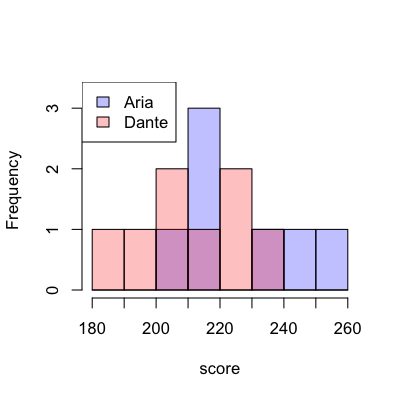

    To run the test, first calculate the observed absolute difference of sample means.
    - Aria’s sample mean = $\bar{x}_1 =$
    - Dante’s sample mean = $\bar{x}_2 =$
    - The absolute difference = $|\bar{x}_2 - \bar{x}_1| =$

## Permutation Test

    1. Reshuffle those two samples 1000 times. I’d recommend [this tool](https://chadworley.github.io/a2/tools/two_list_reshuffler.html), which wants comma-separated data, so here are the samples in that format:

       213, 214, 210, 240, 214, 253, 242

       207, 220, 205, 224, 196, 234, 228, 180

       Notice this reshuffling is equivalent to putting all the scores on cards, shuffling them all together, and then dealing into two piles (repeated 1000 times). Notice, Aria had 7 scores, so one pile always gets 7 numbers, and the other pile gets 8 numbers. We are simulating the hypothesis that maybe both people’s sample came from equivalent populations with a difference of sample means from natural variation, not unequal skill. We will then see if the observed difference is consistent with the simulated differences.
    2. Paste the 1000 rows into a spreadsheet.
    3. For each row, find the absolute difference of the means. Remember, spreadsheets have `=ABS()` for absolute value and `=AVERAGE()` to find a mean.
    4. How many times was the simulation’s absolute difference of means smaller than the observed absolute difference of means. (Choose an interval.)
    5. How many times was the simulation’s difference as big or bigger than the observation’s difference? (Choose an interval.)
    6. What **proportion** of the time was the simulation as big or bigger? (In statistics this is called the $p$-value.) (Choose an interval.)
    7. If the $p$-value is less than 0.05, then the difference is significant. Otherwise, the difference is not significant. Is the difference significant?
    8. So, then, can we conclude that Aria is significantly better than Dante at archery?

#### Solution

#### Question

11. *S-IC.B.5: Use data from a randomized experiment to compare two treatments; use simulations to decide if differences between parameters are significant.*

    Celia and Hugo wonder if they are equally skilled at archery. They decide to compare this year’s scores using a two-tail [approximate permutation test](https://en.wikipedia.org/wiki/Permutation_test), using a significance level of 5%.

    | Celia | Hugo |
    | --- | --- |
    | 201 | 238 |
    | 213 | 181 |
    | 228 | 262 |
    | 228 | 247 |
    | 213 | 204 |
    | 208 | 235 |
    |  | 244 |

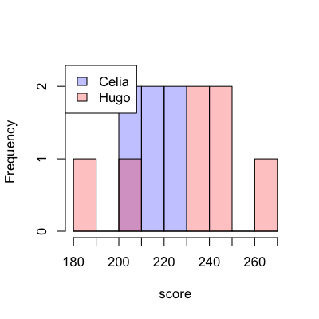

    To run the test, first calculate the observed absolute difference of sample means.
    - Celia’s sample mean = $\bar{x}_1 =$
    - Hugo’s sample mean = $\bar{x}_2 =$
    - The absolute difference = $|\bar{x}_2 - \bar{x}_1| =$

## Permutation Test

    1. Reshuffle those two samples 1000 times. I’d recommend [this tool](https://chadworley.github.io/a2/tools/two_list_reshuffler.html), which wants comma-separated data, so here are the samples in that format:

       201, 213, 228, 228, 213, 208

       238, 181, 262, 247, 204, 235, 244

       Notice this reshuffling is equivalent to putting all the scores on cards, shuffling them all together, and then dealing into two piles (repeated 1000 times). Notice, Celia had 6 scores, so one pile always gets 6 numbers, and the other pile gets 7 numbers. We are simulating the hypothesis that maybe both people’s sample came from equivalent populations with a difference of sample means from natural variation, not unequal skill. We will then see if the observed difference is consistent with the simulated differences.
    2. Paste the 1000 rows into a spreadsheet.
    3. For each row, find the absolute difference of the means. Remember, spreadsheets have `=ABS()` for absolute value and `=AVERAGE()` to find a mean.
    4. How many times was the simulation’s absolute difference of means smaller than the observed absolute difference of means. (Choose an interval.)
    5. How many times was the simulation’s difference as big or bigger than the observation’s difference? (Choose an interval.)
    6. What **proportion** of the time was the simulation as big or bigger? (In statistics this is called the $p$-value.) (Choose an interval.)
    7. If the $p$-value is less than 0.05, then the difference is significant. Otherwise, the difference is not significant. Is the difference significant?
    8. So, then, can we conclude that Hugo is significantly better than Celia at archery?

#### Solution

#### Question

12. *S-IC.B.5: Use data from a randomized experiment to compare two treatments; use simulations to decide if differences between parameters are significant.*

    Wendell and Xena wonder if they are equally skilled at archery. They decide to compare this year’s scores using a two-tail [approximate permutation test](https://en.wikipedia.org/wiki/Permutation_test), using a significance level of 5%.

    | Wendell | Xena |
    | --- | --- |
    | 226 | 222 |
    | 230 | 229 |
    | 227 | 219 |
    | 216 | 220 |
    | 214 | 217 |
    | 210 | 231 |
    | 213 | 234 |
    | 228 | 218 |
    | 208 | 208 |
    | 209 |  |
    | 209 |  |
    | 207 |  |

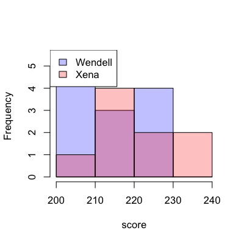

    To run the test, first calculate the observed absolute difference of sample means.
    - Wendell’s sample mean = $\bar{x}_1 =$
    - Xena’s sample mean = $\bar{x}_2 =$
    - The absolute difference = $|\bar{x}_2 - \bar{x}_1| =$

## Permutation Test

    1. Reshuffle those two samples 1000 times. I’d recommend [this tool](https://chadworley.github.io/a2/tools/two_list_reshuffler.html), which wants comma-separated data, so here are the samples in that format:

       226, 230, 227, 216, 214, 210, 213, 228, 208, 209, 209, 207

       222, 229, 219, 220, 217, 231, 234, 218, 208

       Notice this reshuffling is equivalent to putting all the scores on cards, shuffling them all together, and then dealing into two piles (repeated 1000 times). Notice, Wendell had 12 scores, so one pile always gets 12 numbers, and the other pile gets 9 numbers. We are simulating the hypothesis that maybe both people’s sample came from equivalent populations with a difference of sample means from natural variation, not unequal skill. We will then see if the observed difference is consistent with the simulated differences.
    2. Paste the 1000 rows into a spreadsheet.
    3. For each row, find the absolute difference of the means. Remember, spreadsheets have `=ABS()` for absolute value and `=AVERAGE()` to find a mean.
    4. How many times was the simulation’s absolute difference of means smaller than the observed absolute difference of means. (Choose an interval.)
    5. How many times was the simulation’s difference as big or bigger than the observation’s difference? (Choose an interval.)
    6. What **proportion** of the time was the simulation as big or bigger? (In statistics this is called the $p$-value.) (Choose an interval.)
    7. If the $p$-value is less than 0.05, then the difference is significant. Otherwise, the difference is not significant. Is the difference significant?
    8. So, then, can we conclude that Xena is significantly better than Wendell at archery?

#### Solution

#### Question

13. A doctor runs a [controlled experiment](https://en.wikipedia.org/wiki/Randomized_controlled_trial). The participants are randomly assigned to two groups: control and treatment. The participants in the control group are given a [placebo](https://en.wikipedia.org/wiki/Placebo-controlled_study). The participants in the treatment group are given a drug. After several months, each participant’s triglyceride level is measured (in mg/dL).

    | x1 | x2 |
    | --- | --- |
    | 447.2 | 456.4 |
    | 426.4 | 494.2 |
    | 493.5 | 463.1 |
    | 422.6 | 490.8 |
    | 466.5 | 458.5 |
    | 448.7 | 463.3 |
    | 465.8 | 475.1 |
    | 424.7 | 463.2 |
    | 428.1 | 446.1 |
    | 455.1 | 459.6 |
    | 459.9 | 478.0 |
    | 451.7 | 473.2 |
    | 492.1 | 461.2 |
    | 469.0 | 481.9 |
    | 443.6 | 424.5 |
    | 442.7 | 454.8 |
    | 452.2 |  |
    | 397.5 |  |
    | 440.2 |  |
    | 455.3 |  |

    You are asked to perform a two-tail [two-sample Welch’s $t$ test](https://en.wikipedia.org/wiki/Welch%27s_t-test) to determine whether there is a significant difference of means in the two samples.
    - Determine the $p$-value. Answers within a tolerance of 0.005 will be accepted.

    Remember, if $p$-value$<0.05$, the difference is significant. Otherwise, the difference is not significant.

#### Solution

#### Question

14. A doctor runs a [controlled experiment](https://en.wikipedia.org/wiki/Randomized_controlled_trial). The participants are randomly assigned to two groups: control and treatment. The participants in the control group are given a [placebo](https://en.wikipedia.org/wiki/Placebo-controlled_study). The participants in the treatment group are given a drug. After several months, each participant’s triglyceride level is measured (in mg/dL).

    | x1 | x2 |
    | --- | --- |
    | 500.7 | 505.9 |
    | 536.3 | 508.6 |
    | 518.6 | 481.7 |
    | 514.5 | 517.0 |
    | 502.1 | 427.5 |
    | 498.4 | 472.2 |
    | 501.6 | 410.9 |
    | 477.5 | 524.7 |
    | 510.2 | 585.8 |
    | 498.7 | 439.9 |
    | 478.0 | 466.1 |
    | 497.5 | 477.4 |
    | 491.4 | 468.9 |
    | 520.7 | 424.2 |
    | 481.2 | 547.1 |
    | 505.4 | 500.9 |
    |  | 547.9 |
    |  | 428.4 |

    You are asked to perform a two-tail [two-sample Welch’s $t$ test](https://en.wikipedia.org/wiki/Welch%27s_t-test) to determine whether there is a significant difference of means in the two samples.
    - Determine the $p$-value. Answers within a tolerance of 0.005 will be accepted.

    Remember, if $p$-value$<0.05$, the difference is significant. Otherwise, the difference is not significant.

#### Solution

#### Question

15. A doctor runs a [controlled experiment](https://en.wikipedia.org/wiki/Randomized_controlled_trial). The participants are randomly assigned to two groups: control and treatment. The participants in the control group are given a [placebo](https://en.wikipedia.org/wiki/Placebo-controlled_study). The participants in the treatment group are given a drug. After several months, each participant’s triglyceride level is measured (in mg/dL).

    | x1 | x2 |
    | --- | --- |
    | 276.4 | 267.1 |
    | 279.9 | 241.1 |
    | 292.7 | 321.1 |
    | 262.5 | 266.8 |
    | 257.3 | 258.2 |
    | 272.0 | 237.6 |
    | 282.3 | 247.1 |
    | 279.4 | 250.8 |
    | 247.3 | 301.5 |
    | 256.6 | 276.0 |
    | 298.3 | 276.4 |
    | 284.7 | 219.2 |
    | 307.1 | 280.0 |
    | 247.2 | 207.7 |
    | 259.3 | 221.9 |
    | 284.5 | 270.9 |
    | 245.3 | 276.8 |
    | 264.0 |  |
    | 280.0 |  |
    | 285.5 |  |

    You are asked to perform a two-tail [two-sample Welch’s $t$ test](https://en.wikipedia.org/wiki/Welch%27s_t-test) to determine whether there is a significant difference of means in the two samples.
    - Determine the $p$-value. Answers within a tolerance of 0.005 will be accepted.

    Remember, if $p$-value$<0.05$, the difference is significant. Otherwise, the difference is not significant.

#### Solution